# VTI Analysis

jy

2023-04-30

## VTI Analysis

Looking at trends, recent status, and expectations for [Vanguard Total Stock Market Index ETF (VTI)](https://investor.vanguard.com/investment-products/etfs/profile/vti) as an exercise in simple quantitative financial analysis.

This ETF covers the whole US stock market, so makes an interesting case to analyze, using various features available within R.

## Get Data

```r
getSymbols(c("VTI","^GSPC"), auto.assign=TRUE) ## auto.assign=TRUE saves object; FALSE prints out data
```

```
## [1] "VTI"  "GSPC"
```

```r
## viz
dygraph(Cl(VTI))
```

[interactive chart not shown]

```r
dygraph(Cl(GSPC))
```

[interactive chart not shown]

VTI tracks S&P 500 very closely.

## Returns

Prices are all well and good - but **returns** are what matter. Returns are the game.

### Daily Returns

```r
VTI_return <- dailyReturn(VTI)
dygraph(VTI_return)
```

[interactive chart not shown]

```r
## summary stats
summary(VTI_return)
```

```
##      Index            daily.returns
##  Min.   :2007-01-03   Min.   :-0.1138085
##  1st Qu.:2011-01-31   1st Qu.:-0.0044703
##  Median :2015-03-03   Median : 0.0007183
##  Mean   :2015-02-28   Mean   : 0.0003456
##  3rd Qu.:2019-04-01   3rd Qu.: 0.0061103
##  Max.   :2023-04-28   Max.   : 0.1282977
```

#### Distribution of daily returns

How are the daily return values spread out across a range of values?

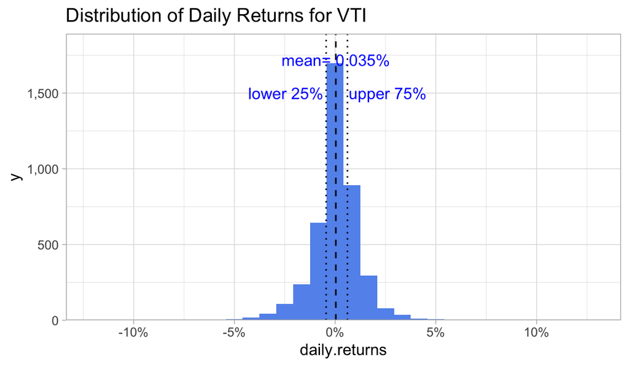

```r
## distribution
#hist(VTI_return)

## convert to data frame for ggplot
VTI_return_df <- data.frame(VTI_return)
VTI_return_df$date <- row.names(VTI_return_df)

VTI_return_df %>% ggplot(aes(x=daily.returns, label=mean(daily.returns)))+
  geom_histogram(fill=bar_fill)+
  geom_vline(xintercept=mean(VTI_return_df$daily.returns), linetype='dashed')+
  geom_vline(xintercept=quantile(VTI_return_df$daily.returns, 0.25), linetype='dotted')+
  geom_vline(xintercept=quantile(VTI_return_df$daily.returns, 0.75), linetype='dotted')+
  annotate(geom = 'text',
           label=paste0("mean= ",prettyNum(mean(VTI_return_df$daily.returns)*100, digits=2),"%"), x=mean(VTI_return_df$daily.returns), y=1720, color='blue')+
  annotate(geom='text', label="lower 25%", x=quantile(VTI_return_df$daily.returns, 0.25)-0.02, color='blue', y=1500)+
  annotate(geom='text', label="upper 75%", x=quantile(VTI_return_df$daily.returns, 0.75)+0.02, color='blue', y=1500)+
  scale_y_continuous(labels=comma, expand=expansion(mult=c(0,0.1)))+
  scale_x_continuous(labels=percent)+
  labs(title='Distribution of Daily Returns for VTI')
```

- Daily returns very tightly centered around 0.

What is the effective annual rate based on mean daily rate?

Even though close to 0 on a daily basis, the average being a little above zero means the return will likely add up and even compaund over a longer period, like a year.

```r
i <- mean(VTI_return_df$daily.returns)
fv <- (1+i)^252-1
paste(prettyNum(fv*100, digits=3),"%")
```

```
## [1] "9.1 %"
```

(using estimated 252 trading days a year)

The actual annual return will depend on where in the data set you are starting and ending the year. We’ll address this further down with rolling return periods.

### Monthly Returns

Let’s take a look at monthly returns.

```r
VTI_return_m <- monthlyReturn(VTI)
## data frame for visualization options
VTI_return_m_df <- as.data.frame(VTI_return_m)
VTI_return_m_df <- VTI_return_m_df %>% rownames_to_column("date")
```

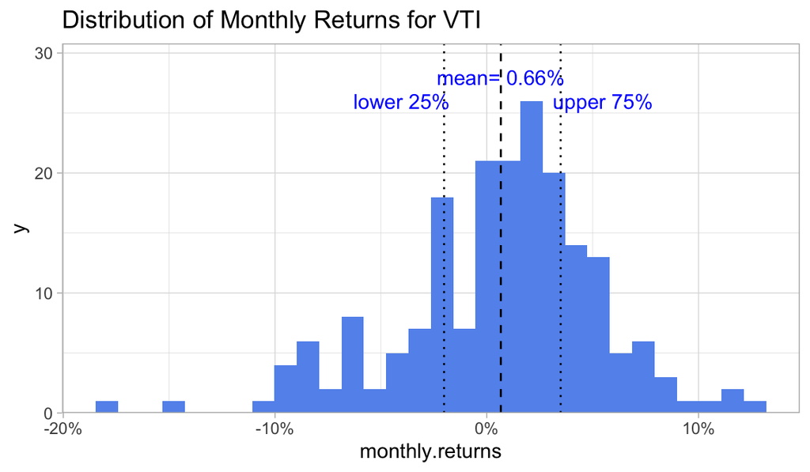

```r
metric <- "monthly.returns"
## data set to use for mean, median, pc calcs
ref_data <- VTI_return_m_df$monthly.returns
y_pr <- 28
y_sec <- 26
y_th <- 24

VTI_return_m_df %>% ggplot(aes(x=.data[[metric]], label=mean(.data[[metric]])))+
  geom_histogram(fill=bar_fill)+
  geom_vline(xintercept=mean(ref_data), linetype='dashed')+
  geom_vline(xintercept=quantile(ref_data, 0.25), linetype='dotted')+
  geom_vline(xintercept=quantile(ref_data, 0.75), linetype='dotted')+
  annotate(geom = 'text',
           label=paste0("mean= ",prettyNum(mean(ref_data)*100, digits=2),"%"), x=mean(ref_data), y=y_pr, color='blue')+
  annotate(geom='text', label="lower 25%", x=quantile(ref_data, 0.25)-0.02, color='blue', y=y_sec)+
  annotate(geom='text', label="upper 75%", x=quantile(ref_data, 0.75)+0.02, color='blue', y=y_sec)+
  scale_y_continuous(labels=comma, expand=expansion(mult=c(0,0.1)))+
  scale_x_continuous(labels=percent)+
  labs(title='Distribution of Monthly Returns for VTI')
```

- More spread in the data, to be expected since it is a longer time period and changes should be larger.
- Average is still close to 0, but noticeably higher than daily average.

```r
i <- mean(VTI_return_m_df$monthly.returns)
fv <- (1+i)^12-1
paste(prettyNum(fv*100, digits=3),"%")
```

```
## [1] "8.24 %"
```

Annualized rate of the average turns out to be a little lower than annualized daily rate.

## Get rolling 1 year returns

Similarly, we can look at annual returns but really this is only meaningful if you are investing right at the beginning of the calendar year and want to know how much return you get at the end of the calendar year. It’s an arbitrary time period.

To better understand what you may expect from any investment over a 1 year time frame we can:

- take the price at end of each month
- compare that to the price at the end of the same month a year ago.
- calculate all those 1 yr returns.

```r
## roll up to months
end_mth <- endpoints(VTI, on="months")
VTIm <- VTI[end_mth,]

VTIm$yr_rtn <- (VTI$VTI.Adjusted/lag.xts(VTIm$VTI.Adjusted, k=12))-1
```

```r
dygraph(VTIm$yr_rtn)
```

[interactive chart not shown]

### Summary stats

```r
summary(VTIm$yr_rtn)
```

```
##      Index                yr_rtn
##  Min.   :2007-01-31   Min.   :-0.433336
##  1st Qu.:2011-02-21   1st Qu.: 0.006801
##  Median :2015-03-15   Median : 0.129921
##  Mean   :2015-03-16   Mean   : 0.103925
##  3rd Qu.:2019-04-06   3rd Qu.: 0.207728
##  Max.   :2023-04-28   Max.   : 0.629253
##                       NA's   :12
```

Data frame for more flexibility in analyzing and visualizing data.

```r
VTIm_df <- as.data.frame(VTIm)
## convert rownames, which are dates, to a date col
VTIm_df <- rownames_to_column(VTIm_df, var="date")
VTIm_df$date <- date(VTIm_df$date)
## add pos or neg indicators
VTIm_df <- VTIm_df %>% mutate(
  status = ifelse(yr_rtn>0,"pos",ifelse(yr_rtn<0,"neg","neutral"))
)
VTIm_df$status <- factor(VTIm_df$status)
```

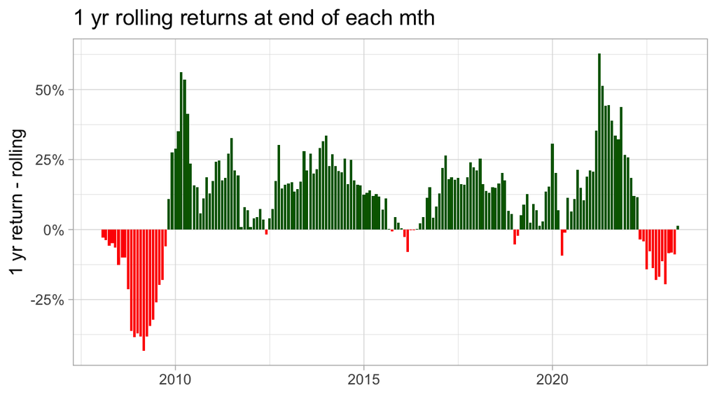

```r
VTIm_df %>% filter(!is.na(yr_rtn)) %>%
  ggplot(aes(x=date, y=yr_rtn))+
  ## prefer geom_area but somehow doesn't work with conditional colors
  ## aggravating!
  geom_col(aes(fill=status))+
  scale_fill_manual(values=c("pos"="darkgreen", "neg"="red"))+
  scale_y_continuous(labels=percent_format())+
  labs(title="1 yr rolling returns at end of each mth", x="", y="1 yr return - rolling")+theme(legend.position = "none")
```

### Distribution

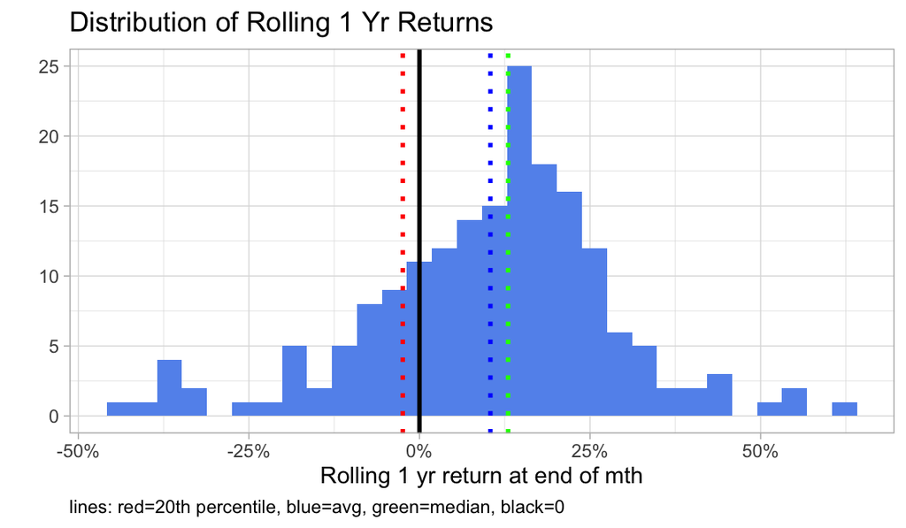

```r
size_spec <- 1
clr_avg <- 'blue'
clr_med <- 'green'
clr_pc_20 <- 'red'
clr_0 <- 'black'
VTIm_df %>% ggplot(aes(x=yr_rtn))+geom_histogram(fill=bar_fill)+
  geom_vline(xintercept = mean(VTIm_df$yr_rtn, na.rm=TRUE), color=clr_avg, linetype='dotted', size=size_spec)+
  scale_x_continuous(labels=percent_format())+
  geom_vline(xintercept = median(VTIm_df$yr_rtn, na.rm=TRUE), color=clr_med, linetype='dotted', size=size_spec)+
  geom_vline(xintercept = quantile(VTIm_df$yr_rtn, 0.20, na.rm=TRUE), color=clr_pc_20, linetype='dotted', size=size_spec)+
  geom_vline(xintercept=0, size=size_spec, color=clr_0)+
  labs(title="Distribution of Rolling 1 Yr Returns",
       x="Rolling 1 yr return at end of mth", y="",
       caption="lines: red=20th percentile, blue=avg, green=median, black=0")+
  theme(plot.caption = element_text(hjust=0))
```

### Expectations

- How likely to get positive annual returns looking back from any month?
- How much can we expect the positive returns to be? (and for negative returns, how much can we expect them to be?)

```r
#VTIm_df$yr_rtn
VTI_pos <- VTIm_df %>% filter(yr_rtn>0)
VTI_neg <- VTIm_df %>% filter(yr_rtn<0)

pc_pos <- round(nrow(VTI_pos)/nrow(VTIm_df),2)
pc_neg <- round(nrow(VTI_neg)/nrow(VTIm_df),2)

avg_pos <- round(mean(VTI_pos$yr_rtn),2)
avg_neg <- round(mean(VTI_neg$yr_rtn),2)
```

- % chance of pos return: **72%**
- avg positive 1 yr return: 18%
- avg neg 1 yr return: -14%

### Periods

What is the longest and average length of consecutive negative period? (in months)

```r
## cumulative count by status -> use rle: run length encoding
runlgth <- rle(as.character(VTIm_df$status))
rl_df <- data.frame(status=runlgth$values, mths=runlgth$lengths)

neg <- rl_df %>% filter(status=='neg')

#max(neg$mths)
#median(neg$mths)
#mean(neg$mths)
```

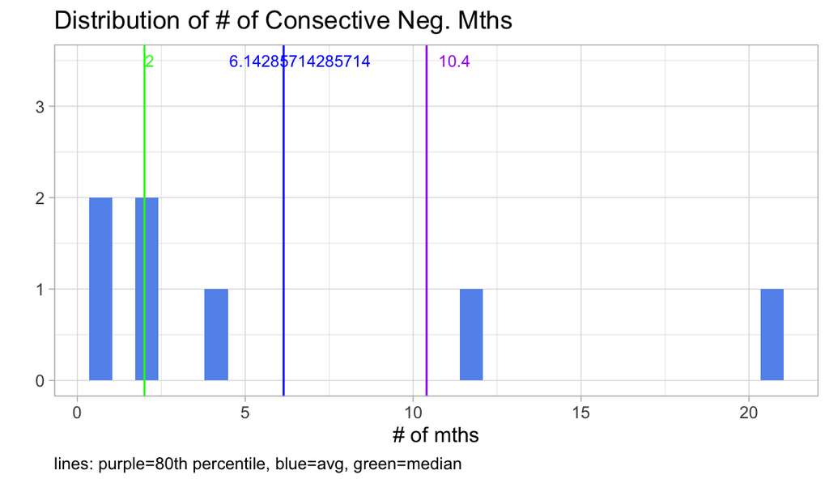

```r
clr_pc_80 <- 'purple'
size_t <- 3
nudge <- 1.08
halign <- 3.5
neg %>% ggplot(aes(x=mths))+
  geom_histogram(fill=bar_fill)+
  geom_vline(xintercept=mean(neg$mths), color=clr_avg)+
  annotate(geom='text', label=mean(neg$mths),
           x=mean(neg$mths)*nudge, y=halign,
           size=size_t, color=clr_avg)+
  geom_vline(xintercept = median(neg$mths), color=clr_med)+
  annotate(geom='text', label=median(neg$mths),
           x=median(neg$mths)*nudge, y=halign,
           size=size_t, color=clr_med)+
  geom_vline(xintercept=quantile(neg$mths, 0.8), color=clr_pc_80)+
  annotate(geom='text', label=quantile(neg$mths, 0.8),
           x=quantile(neg$mths, 0.8)*nudge, y=halign,
           size=size_t, color=clr_pc_80)+
  labs(title='Distribution of # of Consective Neg. Mths',
       x="# of mths", y="",
       caption='lines: purple=80th percentile, blue=avg, green=median')+
  theme(plot.caption=element_text(hjust=0))
```

Stats on number of consecutive months with negative rolling 1 yr returns:

```r
# table for data
tbl_mths_yr <- tribble(
  ~measure, ~`# mths`,
  'max period of neg returns',max(neg$mths),
  'ave period of neg returns',mean(neg$mths),
  'median period of neg returns',median(neg$mths),
  '80th pctile: 80% chance per will be less', quantile(neg$mths, 0.8)
)
gt(tbl_mths_yr)
```

| measure | # mths |
| --- | --- |
| max period of neg returns | 21.000000 |
| ave period of neg returns | 6.142857 |
| median period of neg returns | 2.000000 |
| 80th pctile: 80% chance per will be less | 10.400000 |

## 3 yr rolling

```r
VTIm$yr3_rtn <- (VTI$VTI.Adjusted/lag.xts(VTIm$VTI.Adjusted, k=36))-1

## convert to annualized returns
VTIm$yr3_rtn_an <- (1+VTIm$yr3_rtn)^(1/3)-1
```

```r
#dygraph(VTIm$yr3_rtn)
VTIm[,8:9] %>% dygraph(main='3 yr returns - rolling mthly') %>%
 dySeries('yr3_rtn', label='3 yr return') %>%
 dySeries('yr3_rtn_an', label='3 yr annualized')
```

[interactive chart not shown]

### Summary stats

```r
summary(VTIm$yr3_rtn)
```

```
##      Index               yr3_rtn
##  Min.   :2007-01-31   Min.   :-0.2504
##  1st Qu.:2011-02-21   1st Qu.: 0.3310
##  Median :2015-03-15   Median : 0.4393
##  Mean   :2015-03-16   Mean   : 0.4183
##  3rd Qu.:2019-04-06   3rd Qu.: 0.5707
##  Max.   :2023-04-28   Max.   : 1.0341
##                       NA's   :36
```

```r
summary(VTIm$yr3_rtn_an)
```

```
##      Index              yr3_rtn_an
##  Min.   :2007-01-31   Min.   :-0.0916
##  1st Qu.:2011-02-21   1st Qu.: 0.1000
##  Median :2015-03-15   Median : 0.1291
##  Mean   :2015-03-16   Mean   : 0.1195
##  3rd Qu.:2019-04-06   3rd Qu.: 0.1624
##  Max.   :2023-04-28   Max.   : 0.2671
##                       NA's   :36
```

Data frame for more flexibility in analyzing and visualizing data.

```r
## add new col to existing data frame
VTIm_df <- cbind(VTIm_df, VTIm$yr3_rtn)
VTIm_df <- VTIm_df %>% mutate(
  yr3_rtn_an = (1+yr3_rtn)^(1/3)-1,
  status3 = ifelse(yr3_rtn>0,"pos",ifelse(yr3_rtn<0,"neg","neutral"))
)
```

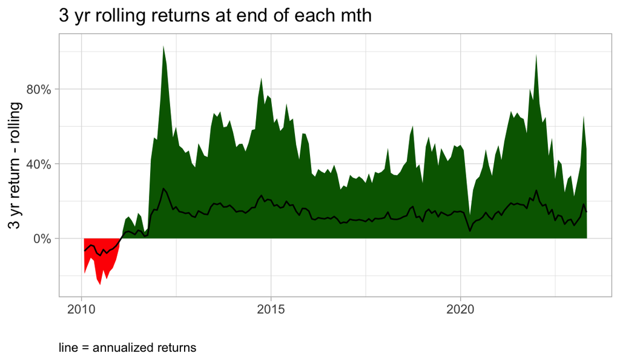

```r
VTIm_df %>% filter(!is.na(yr3_rtn)) %>%
  ggplot(aes(x=date, y=yr3_rtn))+
  ## geom_area works for this one
  geom_area(aes(fill=status3))+
  scale_fill_manual(values=c("pos"="darkgreen", "neg"="red"))+
  ## layer in line for annualized returns
  geom_line(aes(y=yr3_rtn_an))+
  scale_y_continuous(labels=percent_format())+
  labs(title="3 yr rolling returns at end of each mth", x="", y="3 yr return - rolling",
       caption='line = annualized returns')+theme(legend.position = "none", plot.caption=element_text(hjust=0))
```

### Distribution

How are 3 yr returns distributed over the period?

#### 3 yr returns

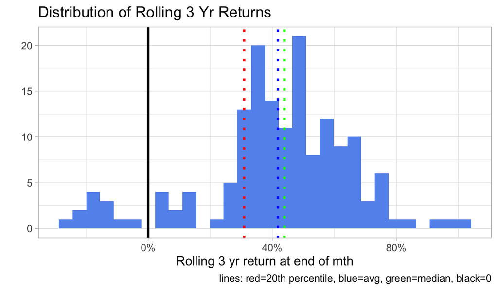

```r
size_spec <- 1
VTIm_df %>% ggplot(aes(x=yr3_rtn))+geom_histogram(fill=bar_fill)+
  geom_vline(xintercept = mean(VTIm_df$yr3_rtn, na.rm=TRUE), color=clr_avg, linetype='dotted', size=size_spec)+
  scale_x_continuous(labels=percent_format())+
  geom_vline(xintercept = median(VTIm_df$yr3_rtn, na.rm=TRUE), color=clr_med, linetype='dotted', size=size_spec)+
  geom_vline(xintercept = quantile(VTIm_df$yr3_rtn, 0.20, na.rm=TRUE), color=clr_pc_20, linetype='dotted', size=size_spec)+
  geom_vline(xintercept=0, size=size_spec, color=clr_0)+
  labs(title="Distribution of Rolling 3 Yr Returns",
       x="Rolling 3 yr return at end of mth", y="",
       caption="lines: red=20th percentile, blue=avg, green=median, black=0")
```

#### Annualized for comparison

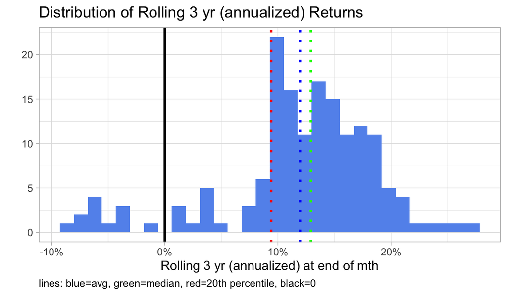

```r
cut <- '3 yr (annualized)'
metric <- 'yr3_rtn_an'
## data set to use for mean, median, pc calcs
ref_data <- VTIm_df$yr3_rtn_an
qtle <- 0.20 # set percentile
# formatting
clr_qtle <- clr_pc_20
clr_avg <- clr_avg
clr_med <- clr_med
clr_0 <- clr_0
size_pr <- 1
ltype_pr <- 'dotted'

## chart
VTIm_df %>% ggplot(aes(x=.data[[metric]]))+
  geom_histogram(fill=bar_fill)+
  scale_x_continuous(labels=percent_format())+
  geom_vline(xintercept=mean(ref_data, na.rm=TRUE),
             color=clr_avg,
             linetype=ltype_pr,
             size=size_pr)+
    geom_vline(xintercept=median(ref_data, na.rm=TRUE),
             color=clr_med,
             linetype=ltype_pr,
             size=size_pr)+
    geom_vline(xintercept=quantile(ref_data, qtle, na.rm=TRUE),
             color=clr_qtle,
             linetype=ltype_pr,
             size=size_pr)+
  geom_vline(xintercept=0,
             size=size_pr,
             color=clr_0)+
  labs(title=paste0("Distribution of Rolling ",cut," Returns"),
       x=paste0("Rolling ", cut," at end of mth"),
       y="",
       caption=paste0("lines: ",clr_avg,"=avg, ", clr_med,"=median, ",clr_qtle,"=",qtle*100,"th percentile, ",clr_0,"=0"))+
  theme(plot.caption=element_text(hjust=0))
```

### Expectations

- How likely to get positive 3 yr returns looking back from any month?
- How much can we expect the positive returns to be? (and for negative returns, how much can we expect them to be?)

```r
#VTIm_df$yr_rtn
VTI_pos <- VTIm_df %>% filter(yr3_rtn>0)
VTI_neg <- VTIm_df %>% filter(yr3_rtn<0)

pc_pos <- round(nrow(VTI_pos)/nrow(VTIm_df),2)
pc_neg <- round(nrow(VTI_neg)/nrow(VTIm_df),2)

avg_pos <- round(mean(VTI_pos$yr3_rtn),2)
avg_neg <- round(mean(VTI_neg$yr3_rtn),2)

## annualized
avg_pos_an <- round(mean(VTI_pos$yr3_rtn_an),2)
avg_neg_an <- round(mean(VTI_neg$yr3_rtn_an),2)
```

- % chance of pos 3 yr return: **76%**
- avg positive 3 yr total return: 47%
- avg neg 3 yr total return: -16%

On annualized basis:

- avg positive 3 yr total return: 13%
- avg neg 3 yr total return: -6%

## Initial Conclusions

Past results do not guarantee similar future results. This is a limited sample of historical information.

That said, this data suggests the investment is very reliable over the longer term, beyond 1 yr and especially beyond 3 yrs.

- much higher % of cases (months) with positive returns.
- ave annualized returns well above typical ‘risk-free’ rate suggest good risk/return ratio.

## Time Series Analysis

### Decompose

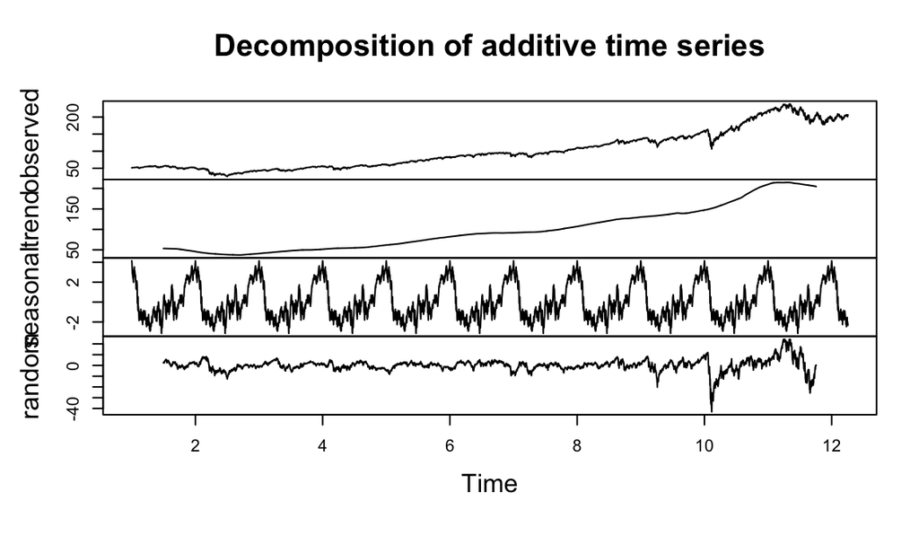

```r
vti_dc <- decompose(ts(VTI$VTI.Adjusted, frequency=365), type='additive')
plot(vti_dc)
```

Can see:

- gradual upward trend, acceleratiing in recent periods.
- seasonal pattern within the years: looks like starts high, drops off in early part of year and then climbs back up.

### Trends

```r
vti_df <- data.frame(VTI)
vti_df$date <- index(VTI)
```

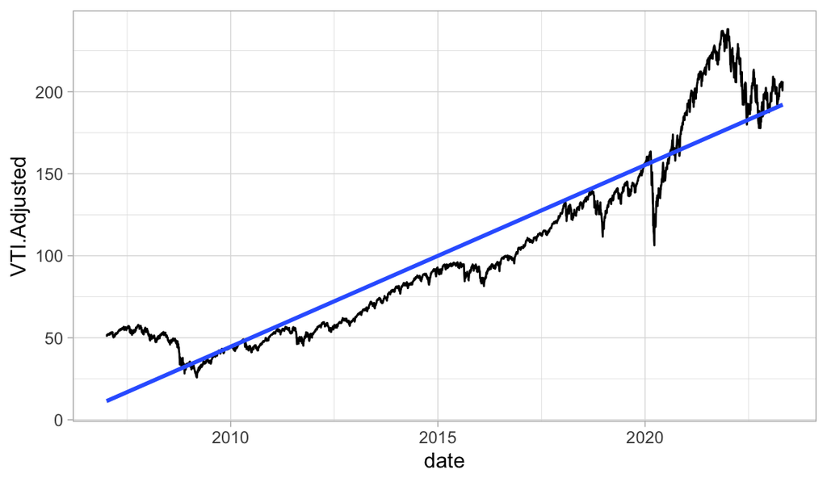

```r
vti_df %>% ggplot(aes(x=date, y=VTI.Adjusted))+geom_line()+
  geom_smooth(method='lm')
```

### Linear model

Linear model based on VTI.Adjusted:

(technically DUBIOUS to use linear regression with time series, because violates the autocorrelation rule: residuals should not be correlated.)

```r
vti_lm <- lm(formula=VTI.Adjusted~date, data=vti_df)
summary(vti_lm)
```

```
##
## Call:
## lm(formula = VTI.Adjusted ~ date, data = vti_df)
##
## Residuals:
##     Min      1Q  Median      3Q     Max
## -51.443 -13.086  -7.250   5.037  61.227
##
## Coefficients:
##                 Estimate   Std. Error t value Pr(>|t|)
## (Intercept) -398.4219414    2.9761834  -133.9   <2e-16 ***
## date           0.0303215    0.0001795   169.0   <2e-16 ***
## ---
## Signif. codes:  0 '***' 0.001 '**' 0.01 '*' 0.05 '.' 0.1 ' ' 1
##
## Residual standard error: 19.8 on 4107 degrees of freedom
## Multiple R-squared:  0.8742, Adjusted R-squared:  0.8742
## F-statistic: 2.855e+04 on 1 and 4107 DF,  p-value: < 2.2e-16
```

#### Remove Data 2020 and Beyond

- since looks like anamoly - want to focus on more reliable patterns

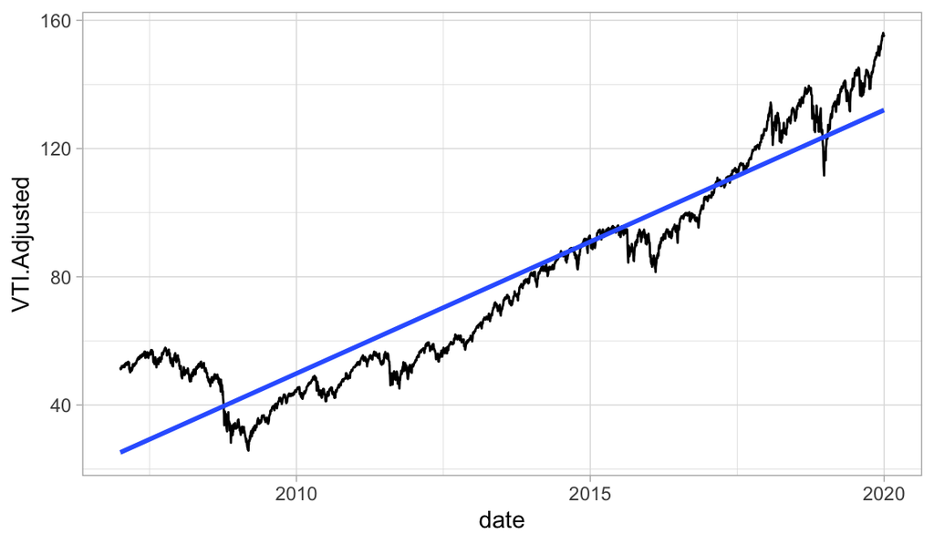

```r
vti_df_2020 <- vti_df %>% filter(date<='2019-12-31')
vti_df_2020 %>% ggplot(aes(x=date, y=VTI.Adjusted))+geom_line()+
  geom_smooth(method='lm')
```

```r
vti_2020_lm <- lm(formula=VTI.Adjusted~date, data=vti_df_2020)
summary(vti_2020_lm)
```

```
##
## Call:
## lm(formula = VTI.Adjusted ~ date, data = vti_df_2020)
##
## Residuals:
##     Min      1Q  Median      3Q     Max
## -19.090  -8.555  -3.723   8.299  28.048
##
## Coefficients:
##                 Estimate   Std. Error t value Pr(>|t|)
## (Intercept) -278.9775495    2.3193992  -120.3   <2e-16 ***
## date           0.0225061    0.0001454   154.7   <2e-16 ***
## ---
## Signif. codes:  0 '***' 0.001 '**' 0.01 '*' 0.05 '.' 0.1 ' ' 1
##
## Residual standard error: 11.4 on 3270 degrees of freedom
## Multiple R-squared:  0.8798, Adjusted R-squared:  0.8798
## F-statistic: 2.394e+04 on 1 and 3270 DF,  p-value: < 2.2e-16
```

```r
## pre-2020 lm to make predictions of close for whole set
pvti <- vti_df %>% select(date)
pvti$clpred <- predict(vti_2020_lm, newdata=pvti)

vti_dfp <- left_join(vti_df, pvti, by='date')
```

Expected trend beyond 2019 based on linear model for pre-2020 period:

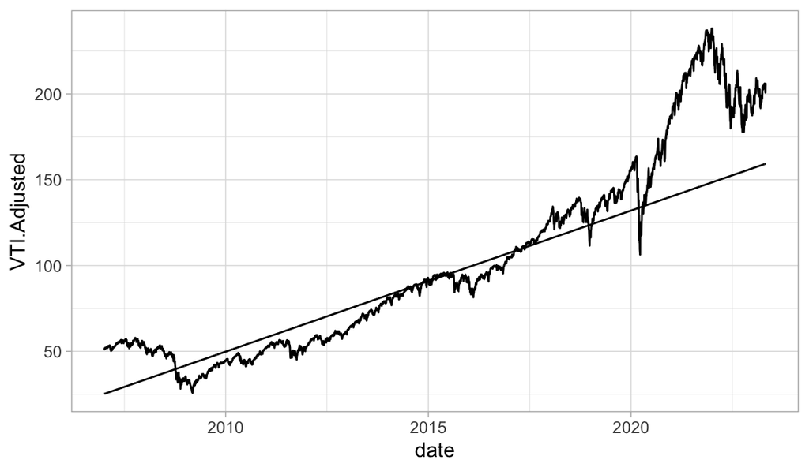

```r
vti_dfp %>% ggplot(aes(x=date, y=VTI.Adjusted))+geom_line()+
  geom_line(aes(y=clpred))
```

### Forecasting

One conclusion could be that VTI is currently over-priced and should be closer to 160 to be in line with historical trends.

Lets extend the prediction out:

- 6 months

```r
## pre-2020 lm to make predictions into the future
pvti <- vti_df %>% select(date)
pvti_6m <- data.frame(date=seq.Date(from=Sys.Date(), to=Sys.Date()+180, by='day'))
pvti <- bind_rows(pvti, pvti_6m)
pvti$clpred6 <- predict(vti_2020_lm, newdata=pvti)

vti_dfp2 <- full_join(vti_df, pvti, by='date')
```

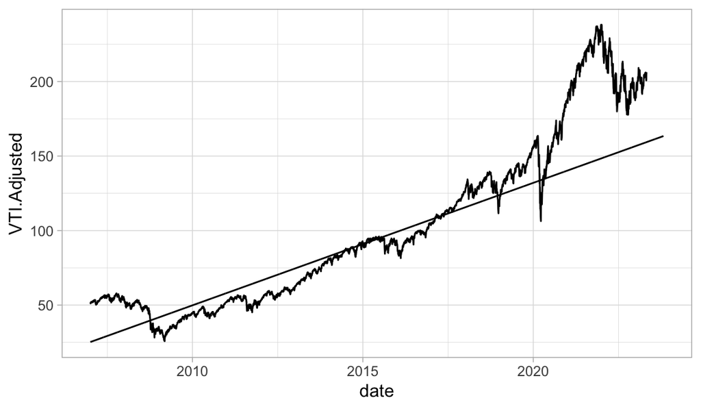

```r
vti_dfp2 %>% ggplot(aes(x=date, y=VTI.Adjusted))+geom_line()+
  geom_line(aes(y=clpred6))
```

- 1 yr out

```r
## pre-2020 lm to make predictions into the future
pvti <- vti_df %>% select(date)
pvti_1y <- data.frame(date=seq.Date(from=Sys.Date(), to=Sys.Date()+365, by='day'))
pvti <- bind_rows(pvti, pvti_1y)
pvti$clpred1y <- predict(vti_2020_lm, newdata=pvti)

vti_dfp3 <- full_join(vti_df, pvti, by='date')
```

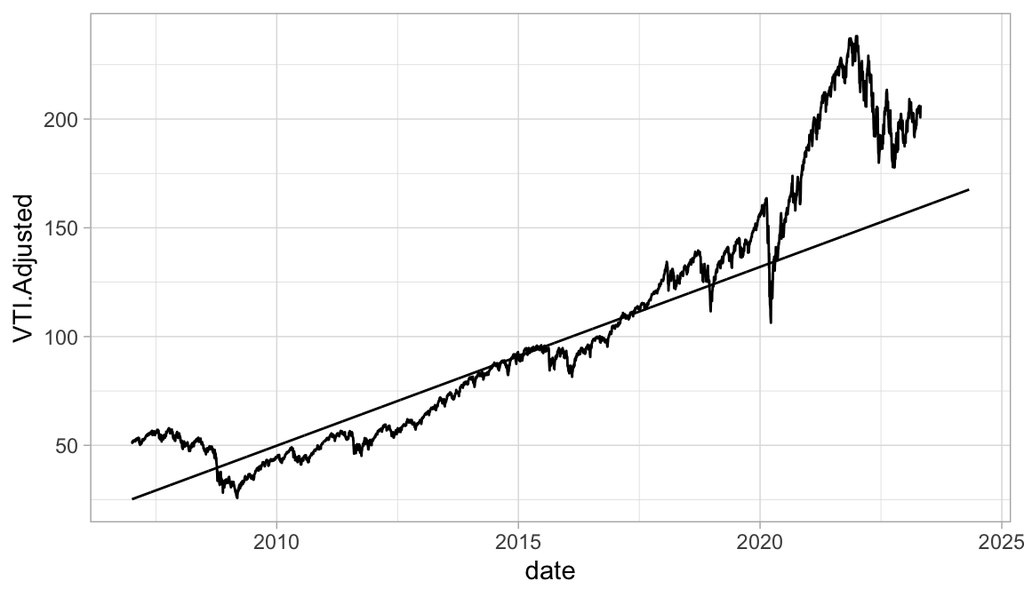

```r
vti_dfp3 %>% ggplot(aes(x=date, y=VTI.Adjusted))+geom_line()+
  geom_line(aes(y=clpred1y))
```

- 5 years out

```r
## pre-2020 lm to make predictions into the future
pvti <- vti_df %>% select(date)
pvti_5y <- data.frame(date=seq.Date(from=Sys.Date(), to=Sys.Date()+(365*5), by='day'))
pvti <- bind_rows(pvti, pvti_5y)
pvti$clpred5y <- predict(vti_2020_lm, newdata=pvti)

vti_dfp5y <- full_join(vti_df, pvti, by='date')
```

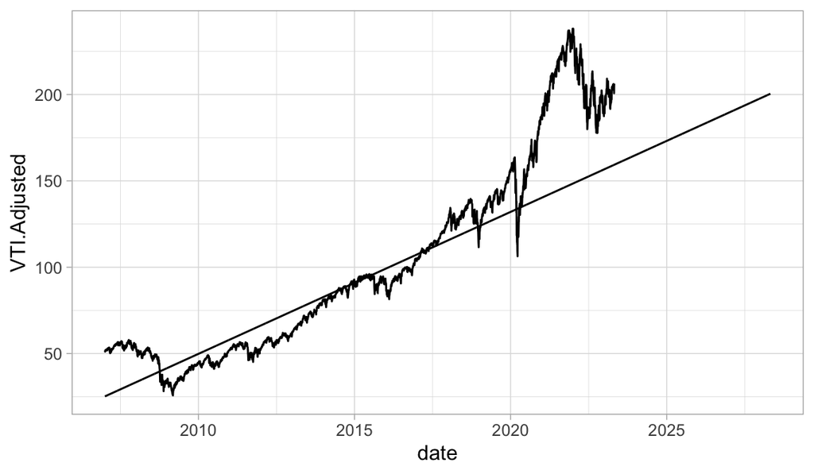

```r
vti_dfp5y %>% ggplot(aes(x=date, y=VTI.Adjusted))+geom_line()+
  geom_line(aes(y=clpred5y))
```

Suggests a conservative scenario would see us around current levels in 5 yrs or so, if reverted back to expectations based on historical trends.

```r
## get most recent value in data
tgt <- tail(VTI, n=1)$VTI.Adjusted
## determine when this should be reached with model
vti_dfp5y %>% filter(clpred5y>=tgt$VTI.Adjusted[[1]]) %>% select(date, clpred5y) %>% filter(date==min(date))
```

```
## [1] date     clpred5y
## <0 rows> (or 0-length row.names)
```

On the other hand, if there is a drop or gradual drift down below the line, could *potentially* represent a promising opportunity over the longer-term.

## Final Conclusion

Obviously simplistic analysis that you wouldn’t want to rely on for serious decisions, but nevertheless interesting for exploration and intellectual amusement.